# DATA 624 - PROJECT 1

OMER OZEREN

# Project 1

```r
library(knitr)
library(ggplot2)
library(tidyr)
library(dplyr)
library(tseries)
library(forecast)
library(lubridate)
library(tidyverse)
library(gridExtra)
library(kableExtra)
```

## Load Data

**Load all three data for the project.**

```r
temp_file <- tempfile(fileext = ".xlsx")
download.file(url = "https://github.com/omerozeren/DATA624/blob/master/Project1/ATM624Data.xlsx?raw=true",
              destfile = temp_file,
              mode = "wb",
              quiet = TRUE)
atm_data <- readxl::read_excel(temp_file,skip=0,col_types = c("date","text","numeric"))
download.file(url = "https://github.com/omerozeren/DATA624/blob/master/Project1/ResidentialCustomerForecastLoad-624.xlsx?raw=true",
              destfile = temp_file,
              mode = "wb",
              quiet = TRUE)
power_data <- readxl::read_excel(temp_file,skip=0,col_types = c("numeric","text","numeric"))
download.file(url = "https://github.com/omerozeren/DATA624/blob/master/Project1/Waterflow_Pipe1.xlsx?raw=true",
              destfile = temp_file,
              mode = "wb",
              quiet = TRUE)
water1_data <- readxl::read_excel(temp_file,skip=0,col_types = c("date","numeric"))
download.file(url = "https://github.com/omerozeren/DATA624/blob/master/Project1/Waterflow_Pipe2.xlsx?raw=true",
              destfile = temp_file,
              mode = "wb",
              quiet = TRUE)
water2_data <- readxl::read_excel(temp_file,skip=0,col_types = c("date","numeric"))
```

## Part A - ATM Forecast

**In part A, I want you to forecast how much cash is taken out of 4 different ATM machines for May 2010. The data is given in a single file. The variable ‘Cash’ is provided in hundreds of dollars, other than that it is straight forward. I am being somewhat ambiguous on purpose to make this have a little more business feeling. Explain and demonstrate your process, techniques used and not used, and your actual forecast. I am giving you data via an excel file, please provide your written report on your findings, visuals, discussion and your R code via an RPubs link along with the actual.rmd file Also please submit the forecast which you will put in an Excel readable file.**

### ATM Data

```r
df<-atm_data %>%
  drop_na() %>%
  spread(ATM, Cash) %>%
  mutate(DATE = as.Date(DATE, origin = "1899-12-30"))
atm_ts<-ts(df %>% select(-DATE))
```

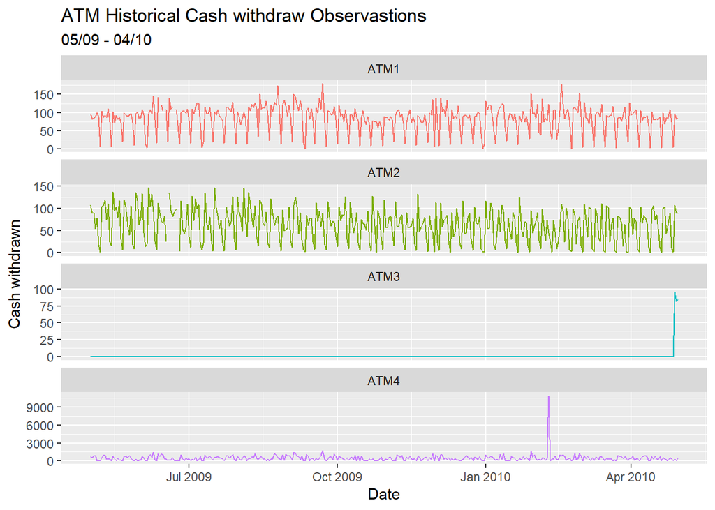

```r
df %>% gather(atm_data, Cash, -DATE) %>%
   ggplot(aes(x = DATE, y = Cash, col = atm_data)) +
   geom_line(show.legend = FALSE) +
   facet_wrap(~ atm_data, ncol = 1, scales = "free_y") +
   labs(title = "ATM Historical Cash withdraw Observastions", subtitle = "05/09 - 04/10", x = "Date") +
   scale_y_continuous("Cash withdrawn ")
```

The plot shows each ATM’s historically cash withdraws.The ATM1 and ATM2 look solid Time series data where they have their own high and lows values. However, ATM3 data has most values zero, that is going to be challenging for building a model.I might need to take just mean valuers of data instead of building time series model.The ATM4 also has some challenges because it cointains some extreme values.

### ATM #1

#### Data Cleanup

```r
atm1 <- atm_data %>%
  filter(ATM == "ATM1")
```

Here, I’d like to review the “atm1” timeseries data to determine whether there is a seosanality and ACF and PACF plots.

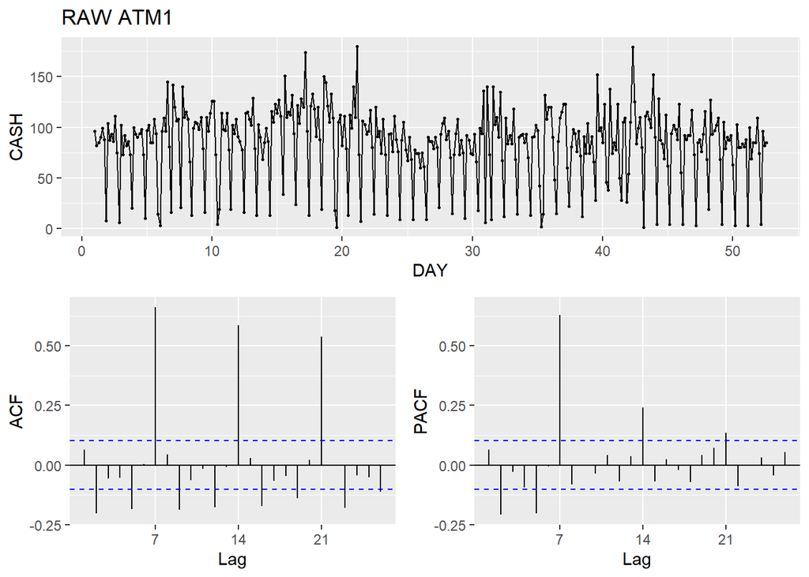

```r
ATM1 <- atm_data[atm_data$ATM == "ATM1",]
ATM1 <- ATM1[complete.cases(ATM1),]
ATM1 <- ts(ATM1[c("Cash")],frequency = 7)
ggtsdisplay(ATM1,
            main = "RAW ATM1",
            xlab = "DAY",
            ylab = "CASH")
```

The ACF plot indicates that observations peak on every 7th lag.I will check Seasonality and Outlier for atm1 data.

#### Outlier and Seasonality

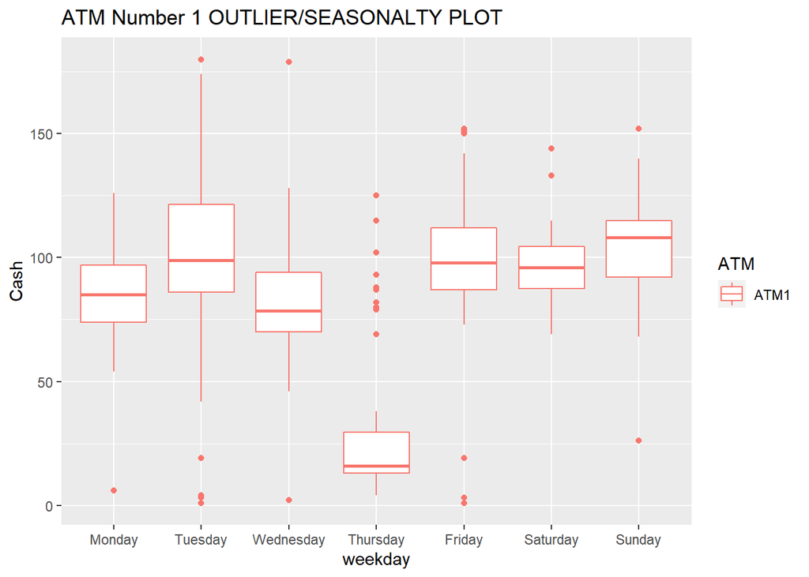

```r
atm1$weekday <- factor(weekdays(as.Date(atm1$DATE)))
atm1$weekday <- ordered(atm1$weekday,levels = c("Monday","Tuesday","Wednesday","Thursday","Friday","Saturday","Sunday"))
#drop NaN values
atm1 <- atm1[complete.cases(atm1),]
ggplot(atm1[complete.cases(atm1),],aes(x=weekday,y=Cash,color=ATM))+
  geom_boxplot()+
  ggtitle("ATM Number 1 OUTLIER/SEASONALTY PLOT")
```

Box plots of the amount of cash is taken by customer in each of days from ATM1.As we can see on plot above, the Sunday has higher mean amount of cash is taken than rest of days.The thursday has the minumum mean of cash amount is taken.The weekdays Tuesdays and Wendsday hold some extreme values (greater than 150).The analysis above drops missing values.

#### Model Creation

I will use following forecating models on this time series and determine which one is better by estimatin error metric RMSE. I will use time series cross validation function to estimate RMSE for timeseries data.

- Seasonal and Trend decomposition (STL)
- Seasonal and Trend decomposition (STL) with ARIMA
- Holt-Winters
- Holt-Winters with Box Cox Adjustment
- ARIMA with Box Cox Adjustment

```r
ATM1 <- atm_data[atm_data$ATM == "ATM1",]
ATM1 <- ATM1[complete.cases(ATM1),]
ATM1 <- ts(ATM1[c("Cash")],frequency = 7)
Box.test(diff(ATM1,lag=7), type = "Ljung-Box")
```

```
##
##  Box-Ljung test
##
## data:  diff(ATM1, lag = 7)
## X-squared = 5.4172, df = 1, p-value = 0.01994
```

```r
kpss.test(diff(ATM1,lag=7))
```

```
##
##  KPSS Test for Level Stationarity
##
## data:  diff(ATM1, lag = 7)
## KPSS Level = 0.021687, Truncation lag parameter = 5, p-value = 0.1
```

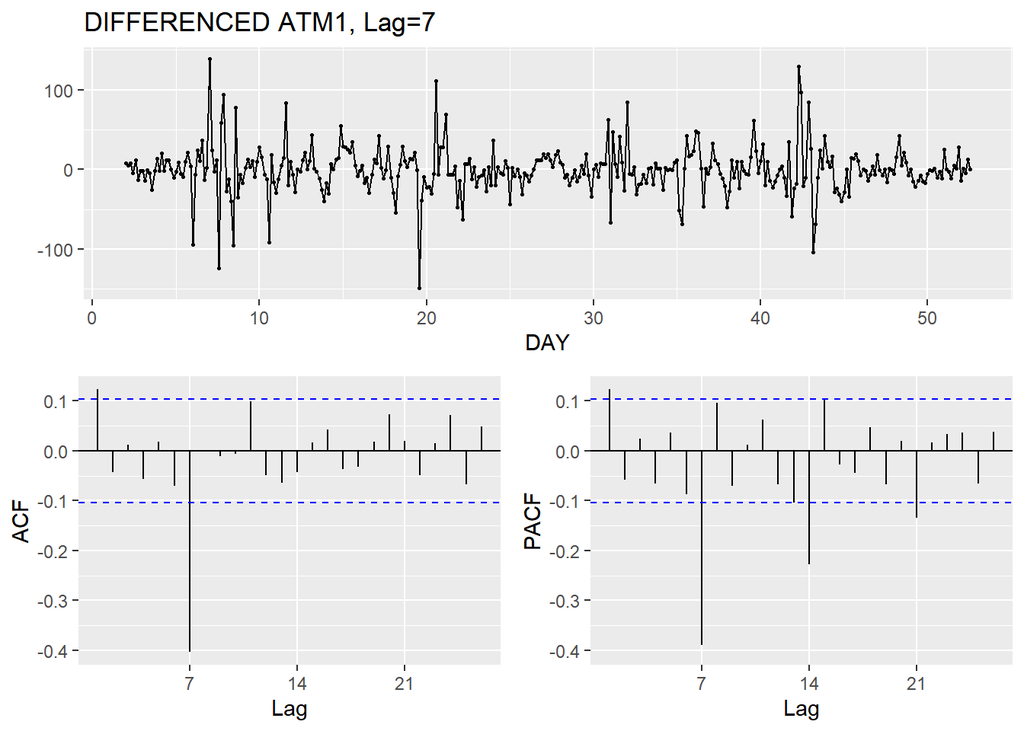

```r
ggtsdisplay(diff(ATM1,lag=7),
            main = "DIFFERENCED ATM1, Lag=7",
            xlab = "DAY",
            ylab = "")
```

The result of KPSS and Box-Cox test indicates that atm1 timeseries is statioanry.

#### Seasonal and Trend decomposition (STL)

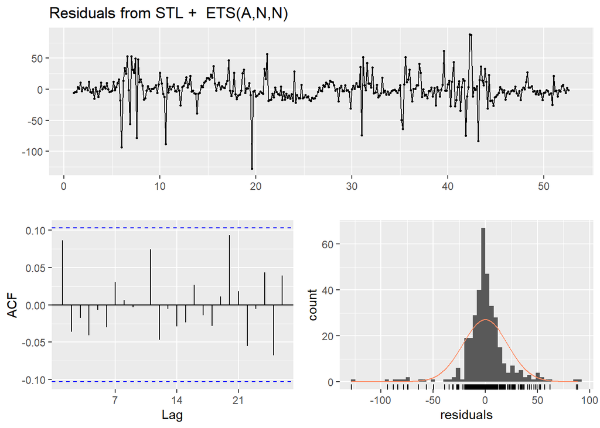

```
##
##  Ljung-Box test
##
## data:  Residuals from STL +  ETS(A,N,N)
## Q* = 7.9258, df = 12, p-value = 0.7909
##
## Model df: 2.   Total lags used: 14
```

```r
atm1_stl_fit <- ATM1 %>%
  stlf(h = 31, s.window = 7, robust = TRUE)
checkresiduals(atm1_stl_fit)
```

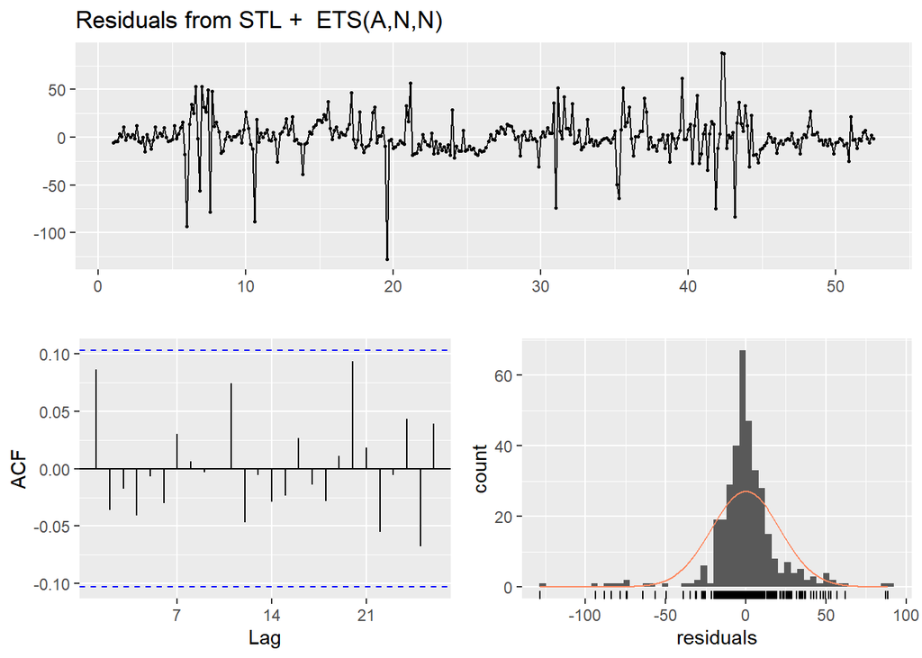

```
##
##  Ljung-Box test
##
## data:  Residuals from STL +  ETS(A,N,N)
## Q* = 7.9258, df = 12, p-value = 0.7909
##
## Model df: 2.   Total lags used: 14
```

```r
checkresiduals(atm1_stl_fit)
```

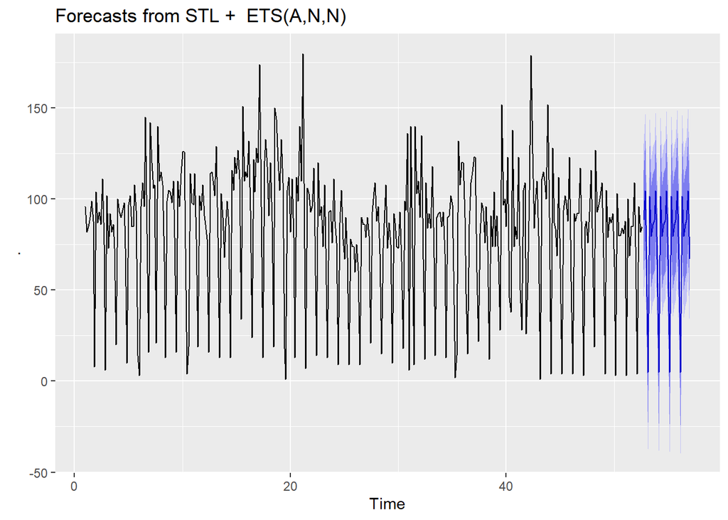

```r
atm1_stl_fit%>% forecast(h=31) %>% autoplot()
```

#### Seasonal and Trend decomposition (STL) with ARIMA

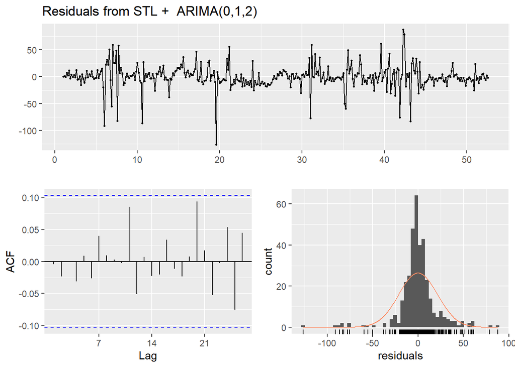

```
##
##  Ljung-Box test
##
## data:  Residuals from STL +  ARIMA(0,1,2)
## Q* = 5.4248, df = 12, p-value = 0.9423
##
## Model df: 2.   Total lags used: 14
```

```r
atm1_stl_arima_fit <- ATM1 %>%
  stlf(h = 31, s.window = 7, robust = TRUE, method = "arima")
checkresiduals(atm1_stl_arima_fit)
```

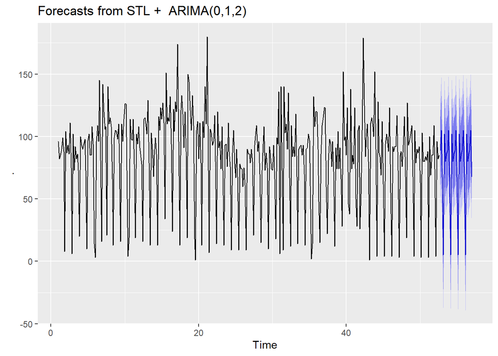

```r
atm1_stl_arima_fit%>% forecast(h=31) %>% autoplot()
```

#### Holt-Winters

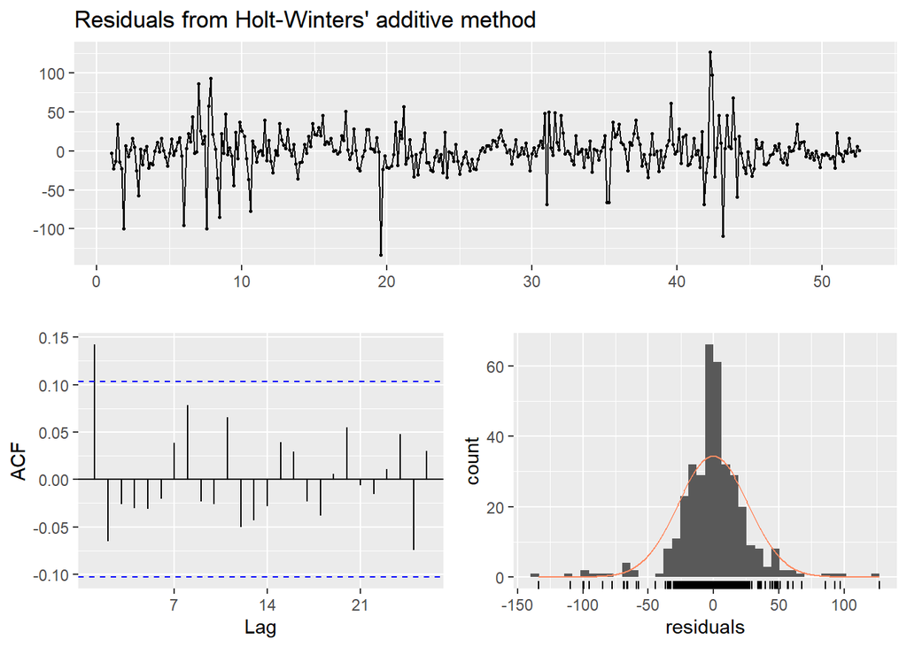

```
##
##  Ljung-Box test
##
## data:  Residuals from Holt-Winters' additive method
## Q* = 16.871, df = 3, p-value = 0.0007513
##
## Model df: 11.   Total lags used: 14
```

```r
atm1_hw_fit <- hw(ATM1, h = 31)
checkresiduals(atm1_hw_fit)
```

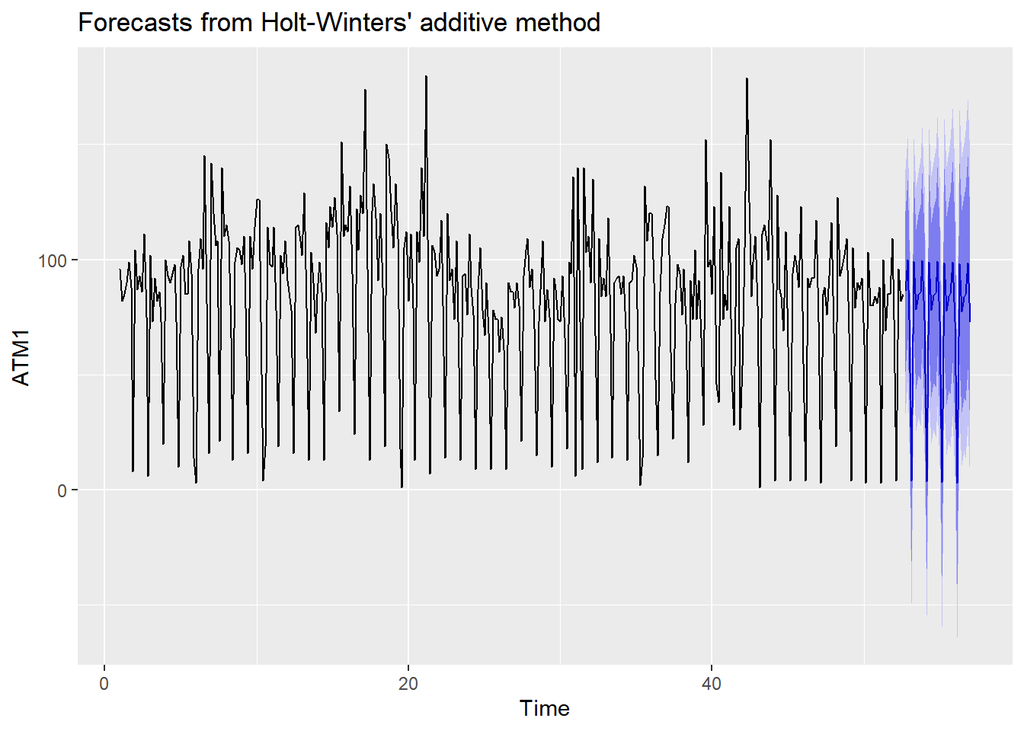

```r
atm1_hw_fit%>% forecast(h=31) %>% autoplot()
```

### Holt-Winters with Box Cox Adjustment

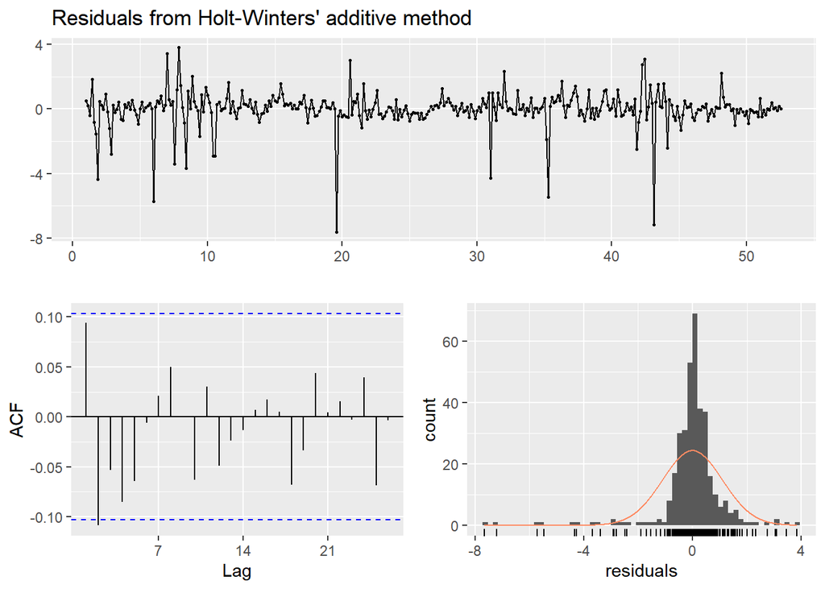

```
##
##  Ljung-Box test
##
## data:  Residuals from Holt-Winters' additive method
## Q* = 16.921, df = 3, p-value = 0.0007336
##
## Model df: 11.   Total lags used: 14
```

```r
atm1_lambda <- BoxCox.lambda(ATM1)
atm1_adj_hw_fit <- hw(ATM1, h = 31, lambda = atm1_lambda)
checkresiduals(atm1_adj_hw_fit)
```

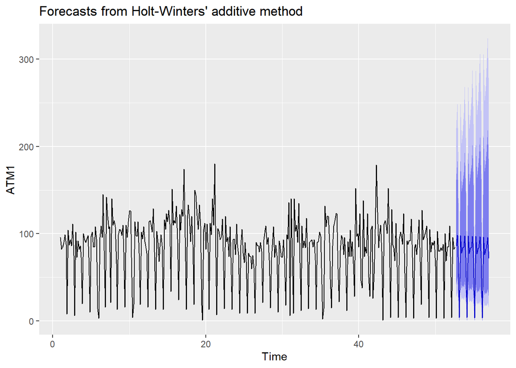

```r
atm1_adj_hw_fit%>% forecast(h=31) %>% autoplot()
```

#### ARIMA

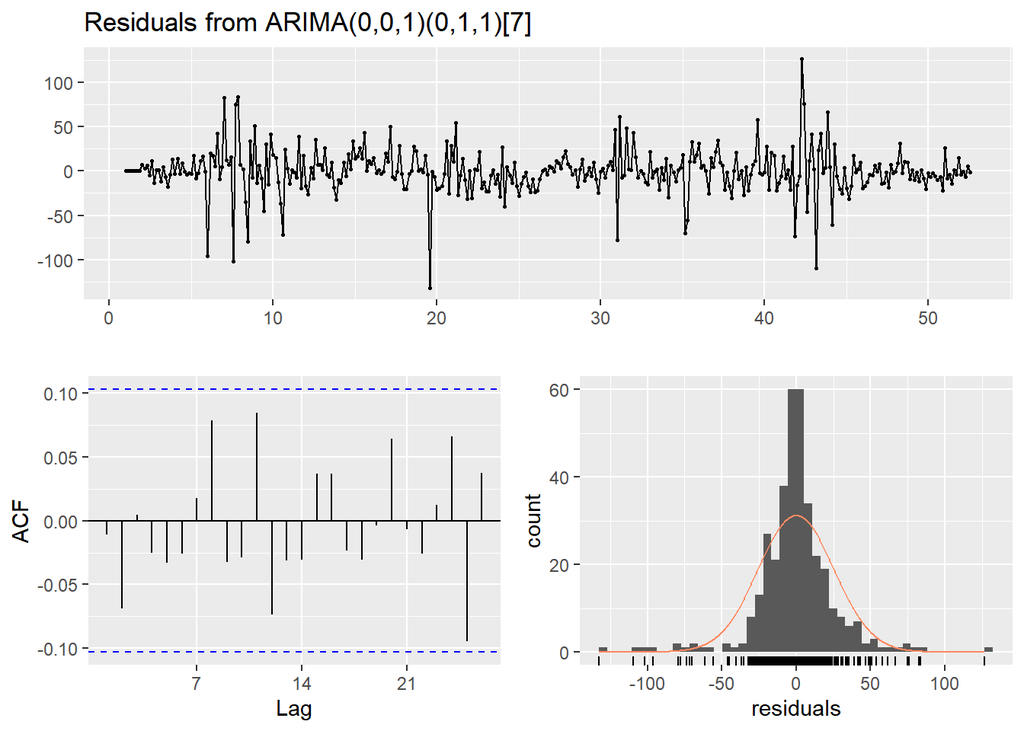

```
##
##  Ljung-Box test
##
## data:  Residuals from ARIMA(0,0,1)(0,1,1)[7]
## Q* = 11.267, df = 12, p-value = 0.5062
##
## Model df: 2.   Total lags used: 14
```

```r
atm1_arima_fit <- auto.arima(ATM1)
checkresiduals(atm1_arima_fit)
```

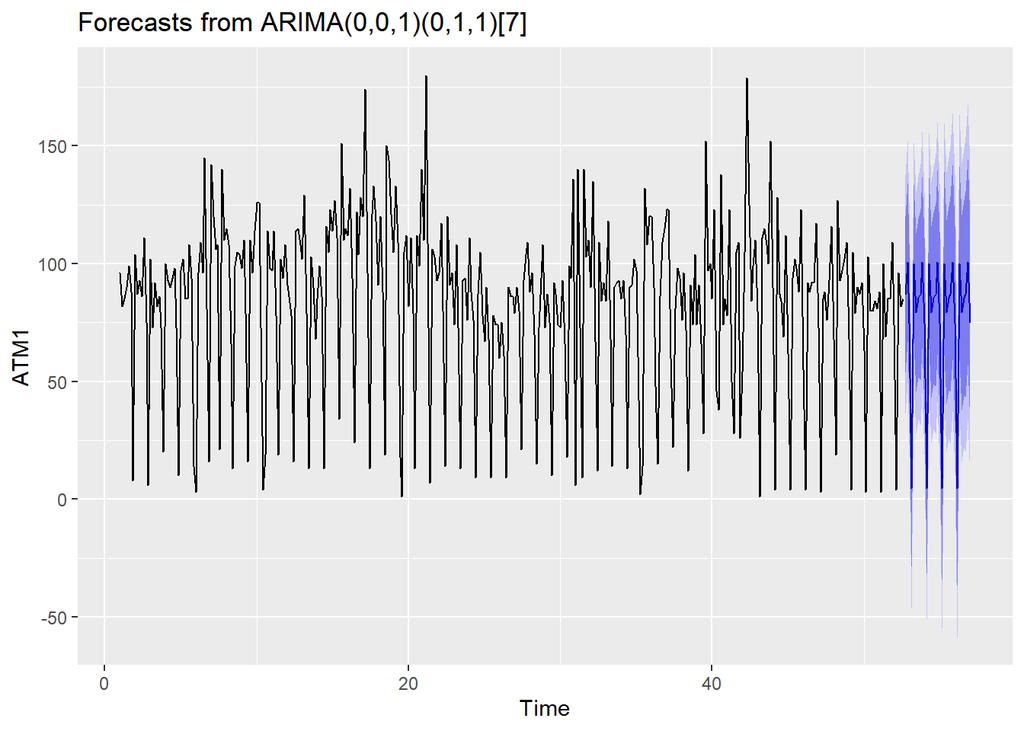

```r
atm1_arima_fit%>% forecast(h=31) %>% autoplot()
```

```r
kpss.test(resid(atm1_arima_fit))
```

```
##
##  KPSS Test for Level Stationarity
##
## data:  resid(atm1_arima_fit)
## KPSS Level = 0.098551, Truncation lag parameter = 5, p-value = 0.1
```

### ARIMA with Box Cox Adjustment

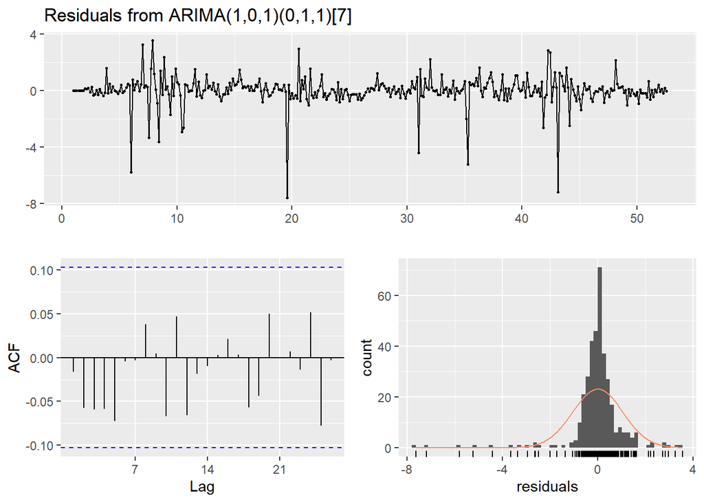

```
##
##  Ljung-Box test
##
## data:  Residuals from ARIMA(1,0,1)(0,1,1)[7]
## Q* = 10.658, df = 11, p-value = 0.4724
##
## Model df: 3.   Total lags used: 14
```

```r
atm1_lambda = BoxCox.lambda(ATM1)
atm1_box_arima_fit <- Arima(ATM1, order = c(1, 0, 1), seasonal = c(0, 1, 1), lambda = atm1_lambda)
checkresiduals(atm1_box_arima_fit)
```

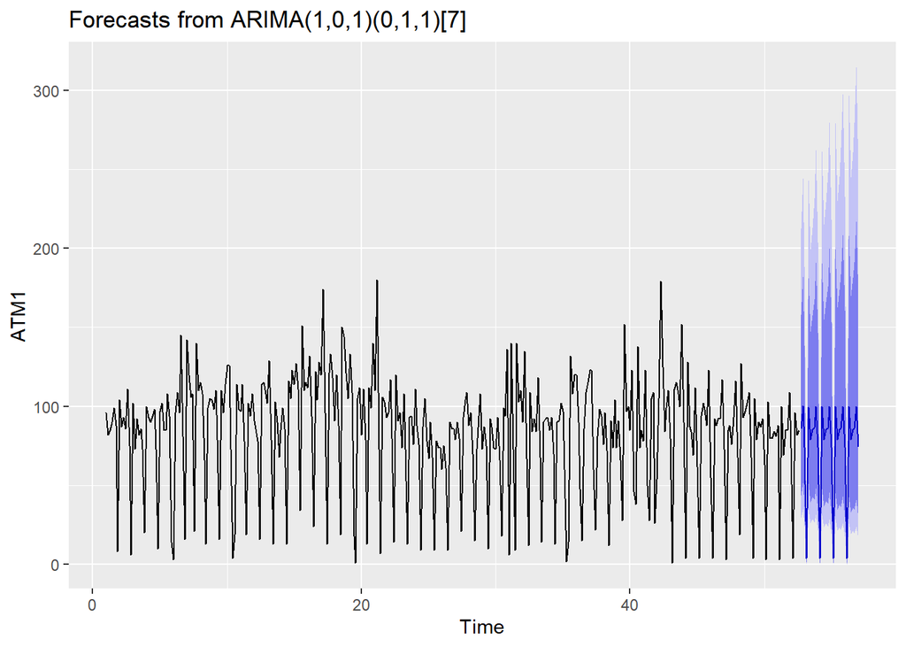

```r
atm1_box_arima_fit%>% forecast(h=31) %>% autoplot()
```

```r
kpss.test(resid(atm1_box_arima_fit))
```

```
##
##  KPSS Test for Level Stationarity
##
## data:  resid(atm1_box_arima_fit)
## KPSS Level = 0.062513, Truncation lag parameter = 5, p-value = 0.1
```

### MODEL EVALUATION

I will use the `tsCV` function and evaluate the models.My goal is to find the model that produces minumum RMSE.

```r
h <- 31
get_rmse <- function(error) {
  sqrt(mean(error^2, na.rm = TRUE))
}
atm1_arima_forecast <- function(x, h) {
  forecast(Arima(x, order = c(0, 0, 1), seasonal = c(0, 1, 1)), h = h)
}
atm1_arima_box_forecast <- function(x, h) {
  forecast(Arima(x, order = c(1, 0, 1), seasonal = c(0, 1, 1),lambda = atm1_lambda), h = h)
}

residuals_stl <- tsCV(ATM1, stlf, h = h, s.window = 7, robust = TRUE)
residuals_stl_arima <- tsCV(ATM1, stlf, h = h, s.window = 7, robust = TRUE, method = "arima")
residuals_hw <- tsCV(ATM1, hw, h = h)
residuals_arima <- tsCV(ATM1, atm1_arima_forecast, h = h)
residuals_arima_box <- tsCV(ATM1, atm1_arima_box_forecast, h = h)
data.frame(Model_Name = c("STL", "STL & ARIMA", "Holt-Winters", "ARIMA","ARIMA-BOX_COX"),
           RMSE = c(get_rmse(residuals_stl[, h]), get_rmse(residuals_stl_arima[, h]), get_rmse(residuals_hw[, h]), get_rmse(residuals_arima[, h]),
                                                                                                                        get_rmse(residuals_arima_box[, h]))) %>%
  arrange(RMSE) %>%
  kable() %>%
  kable_styling()
```

| Model_Name | RMSE |
| --- | --- |
| ARIMA | 35.22610 |
| ARIMA-BOX_COX | 36.14111 |
| STL & ARIMA | 37.99406 |
| STL | 38.75113 |
| Holt-Winters | 46.03976 |

The ARIMA(0,0,1)(0,1,1) model gives the minumum RMSE among the other models.

### ATM #2

#### Data Cleanup

```r
atm2 <- atm_data %>%
  filter(ATM == "ATM2")
```

Here, I’d like to review the “atm2” timeseries data to determine whether there is a seosanality and ACF and PACF plots.

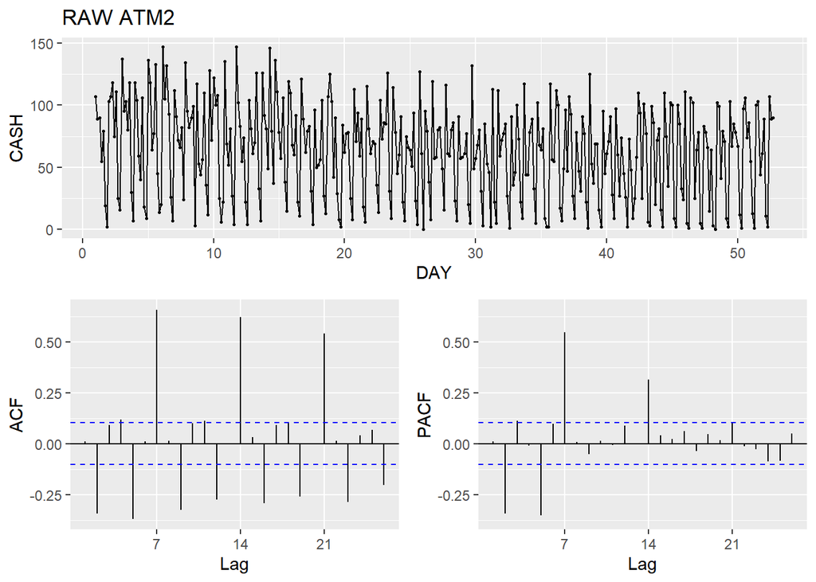

```r
ATM2 <- atm_data[atm_data$ATM == "ATM2",]
ATM2 <- ATM2[complete.cases(ATM2),]
ATM2 <- ts(ATM2[c("Cash")],frequency = 7)
ggtsdisplay(ATM2,
            main = "RAW ATM2",
            xlab = "DAY",
            ylab = "CASH")
```

As above plots, the large spike at lag=2,5,7 suggests I=1,I will check Seasonality and Outlier for atm2 data.

#### Outlier and Seasonality

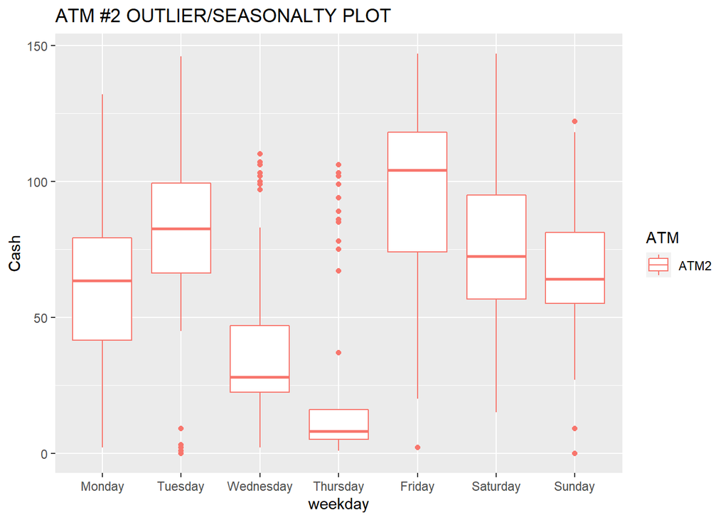

```r
atm2$weekday <- factor(weekdays(as.Date(atm2$DATE)))
atm2$weekday <- ordered(atm2$weekday,levels = c("Monday","Tuesday","Wednesday","Thursday","Friday","Saturday","Sunday"))
#drop NaN values
atm2 <- atm2[complete.cases(atm2),]
ggplot(atm2[complete.cases(atm2),],aes(x=weekday,y=Cash,color=ATM))+
  geom_boxplot()+
  ggtitle("ATM #2 OUTLIER/SEASONALTY PLOT")
```

Box plots of the amount of cash is taken by customer in each of days from ATM2.As we can see on plot above, the Friday has higher mean amount of cash is taken than rest of days.The thursday has the minumum mean of cash amount is taken.

#### Model Creation

I will use following forecating models on this time series and determine which one is better by estimatin error metric RMSE. I will use time series cross validation function to estimate RMSE for timeseries data.

- Seasonal and Trend decomposition (STL)
- Seasonal and Trend decomposition (STL) with ARIMA
- Holt-Winters
- Holt-Winters with Box Cox Adjustment
- ARIMA
- ARIMA with Box Cox Adjustment

```r
ATM2 <- atm_data[atm_data$ATM == "ATM2",]
ATM2 <- ATM2[complete.cases(ATM2),]
ATM2 <- ts(ATM2[c("Cash")],frequency = 7)
Box.test(diff(ATM2,lag=7), type = "Ljung-Box")
```

```
##
##  Box-Ljung test
##
## data:  diff(ATM2, lag = 7)
## X-squared = 0.080312, df = 1, p-value = 0.7769
```

```r
kpss.test(diff(ATM2,lag=7))
```

```
##
##  KPSS Test for Level Stationarity
##
## data:  diff(ATM2, lag = 7)
## KPSS Level = 0.017341, Truncation lag parameter = 5, p-value = 0.1
```

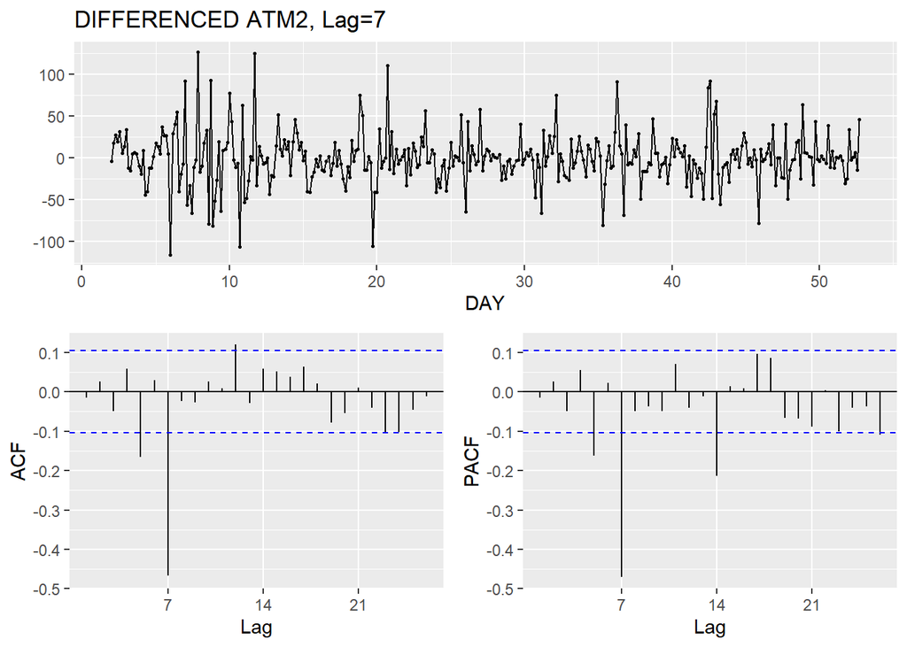

```r
ggtsdisplay(diff(ATM2,lag=7),
            main = "DIFFERENCED ATM2, Lag=7",
            xlab = "DAY",
            ylab = "")
```

#### Seasonal and Trend decomposition (STL)

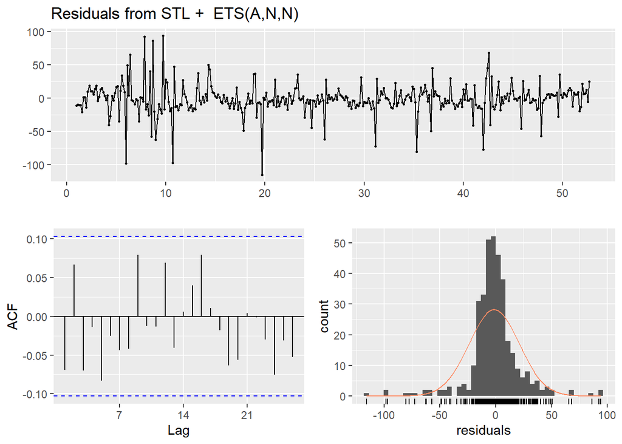

```
##
##  Ljung-Box test
##
## data:  Residuals from STL +  ETS(A,N,N)
## Q* = 14.34, df = 12, p-value = 0.2795
##
## Model df: 2.   Total lags used: 14
```

```r
atm2_stl_fit <- ATM2 %>%
  stlf(h = 31, s.window = 7, robust = TRUE)
checkresiduals(atm2_stl_fit)
```

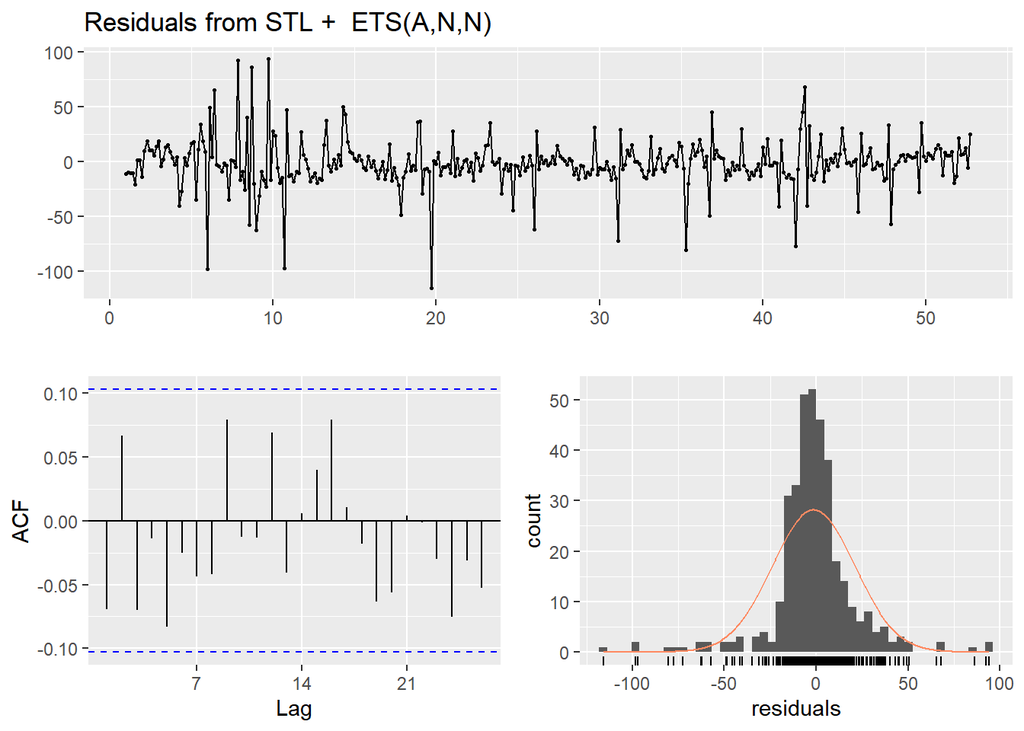

```
##
##  Ljung-Box test
##
## data:  Residuals from STL +  ETS(A,N,N)
## Q* = 14.34, df = 12, p-value = 0.2795
##
## Model df: 2.   Total lags used: 14
```

```r
checkresiduals(atm2_stl_fit)
```

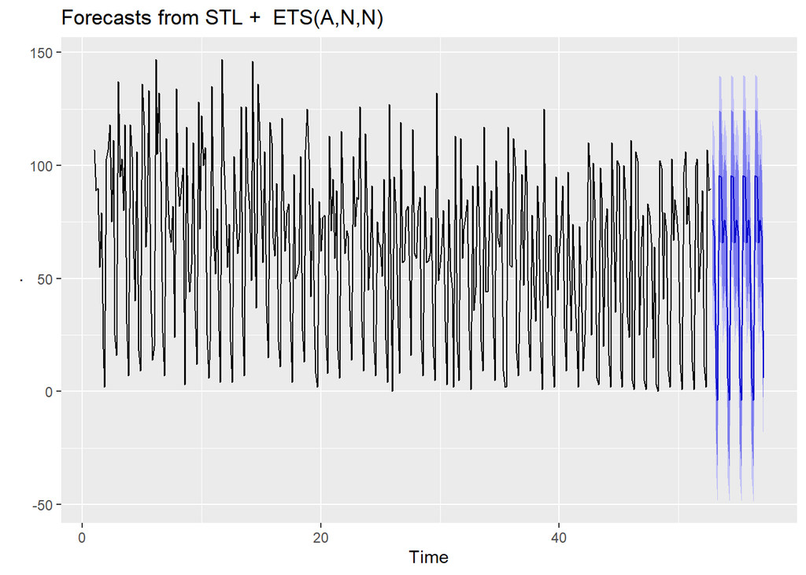

```r
atm2_stl_fit%>% forecast(h=31) %>% autoplot()
```

#### Seasonal and Trend decomposition (STL) with ARIMA

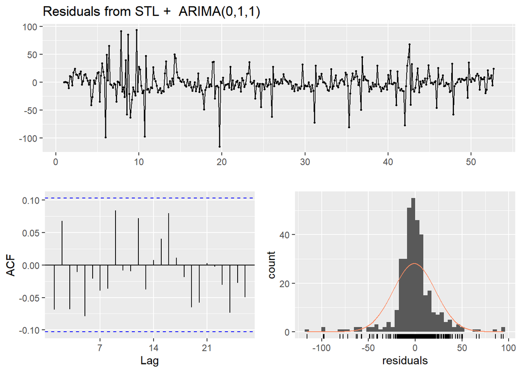

```
##
##  Ljung-Box test
##
## data:  Residuals from STL +  ARIMA(0,1,1)
## Q* = 13.983, df = 13, p-value = 0.375
##
## Model df: 1.   Total lags used: 14
```

```r
atm2_stl_arima_fit <- ATM2 %>%
  stlf(h = 31, s.window = 7, robust = TRUE, method = "arima")
checkresiduals(atm2_stl_arima_fit)
```

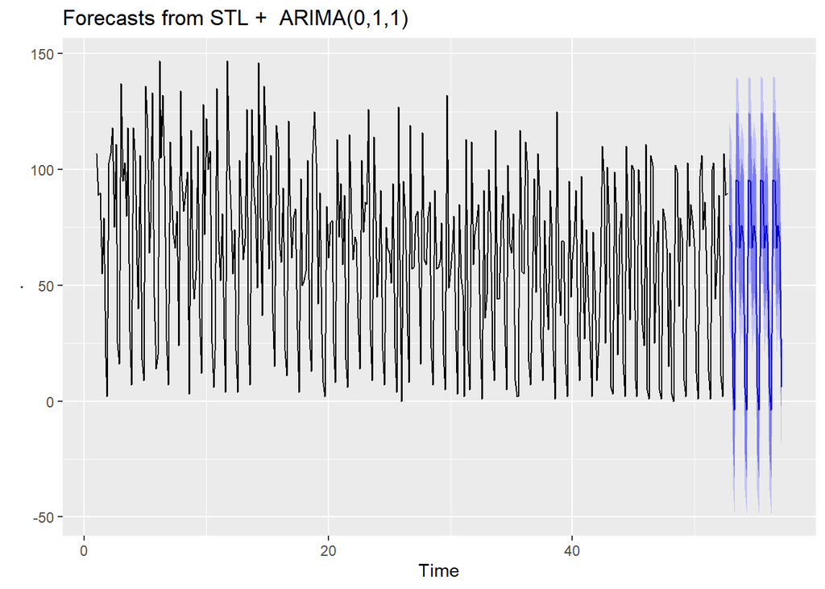

```r
atm2_stl_arima_fit%>% forecast(h=31) %>% autoplot()
```

#### Holt-Winters

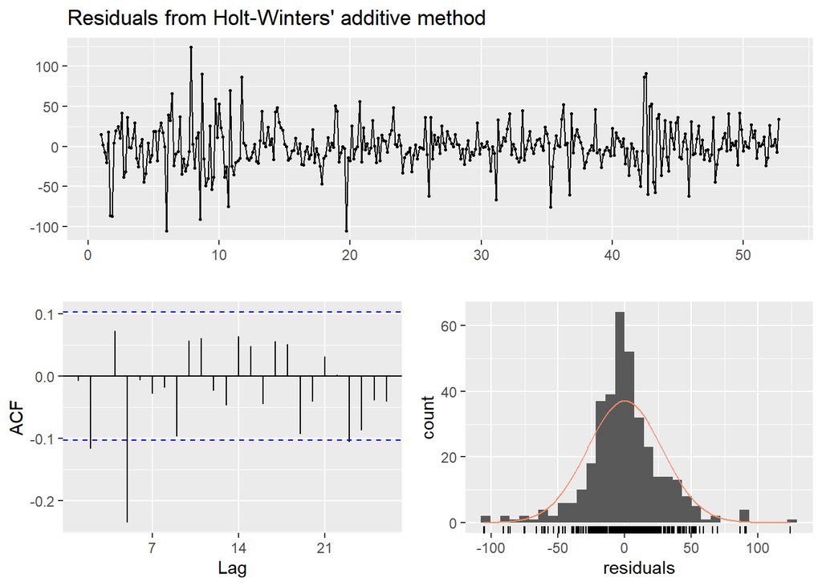

```
##
##  Ljung-Box test
##
## data:  Residuals from Holt-Winters' additive method
## Q* = 36.563, df = 3, p-value = 5.693e-08
##
## Model df: 11.   Total lags used: 14
```

```r
atm2_hw_fit <- hw(ATM2, h = 31)
checkresiduals(atm2_hw_fit)
```

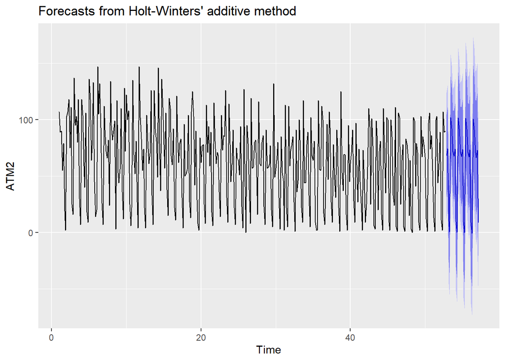

```r
atm2_hw_fit%>% forecast(h=31) %>% autoplot()
```

### Holt-Winters with Box Cox Adjustment

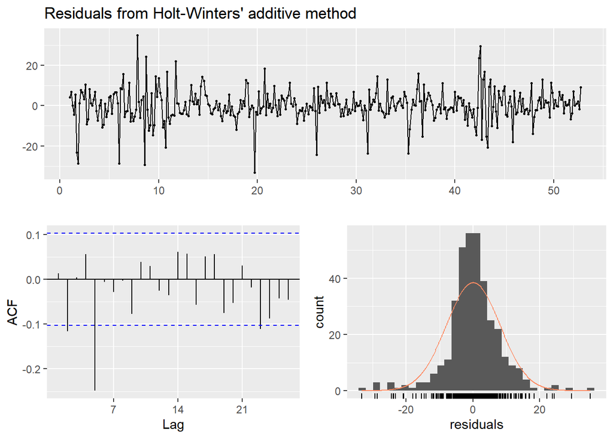

```
##
##  Ljung-Box test
##
## data:  Residuals from Holt-Winters' additive method
## Q* = 34.635, df = 3, p-value = 1.455e-07
##
## Model df: 11.   Total lags used: 14
```

```r
atm2_lambda <- BoxCox.lambda(ATM2)
atm2_adj_hw_fit <- hw(ATM2, h = 31, lambda = atm2_lambda)
checkresiduals(atm2_adj_hw_fit)
```

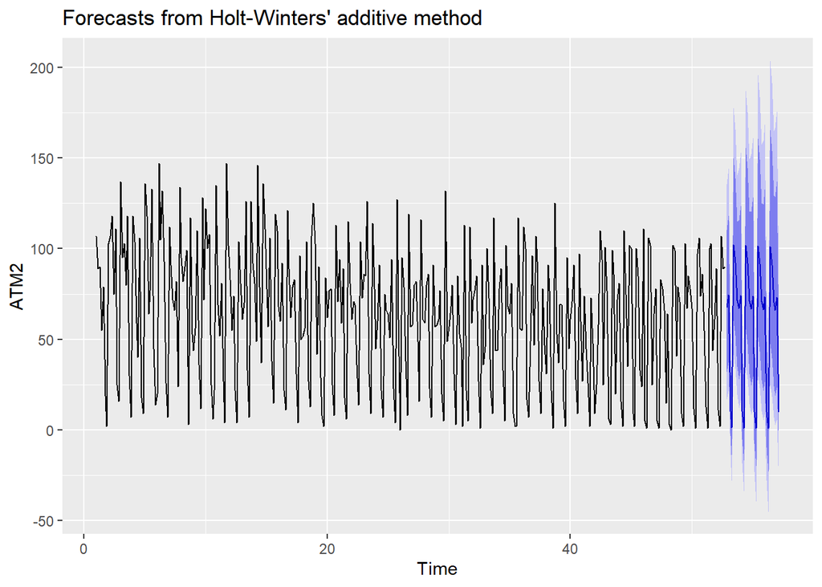

```r
atm2_adj_hw_fit%>% forecast(h=31) %>% autoplot()
```

#### ARIMA

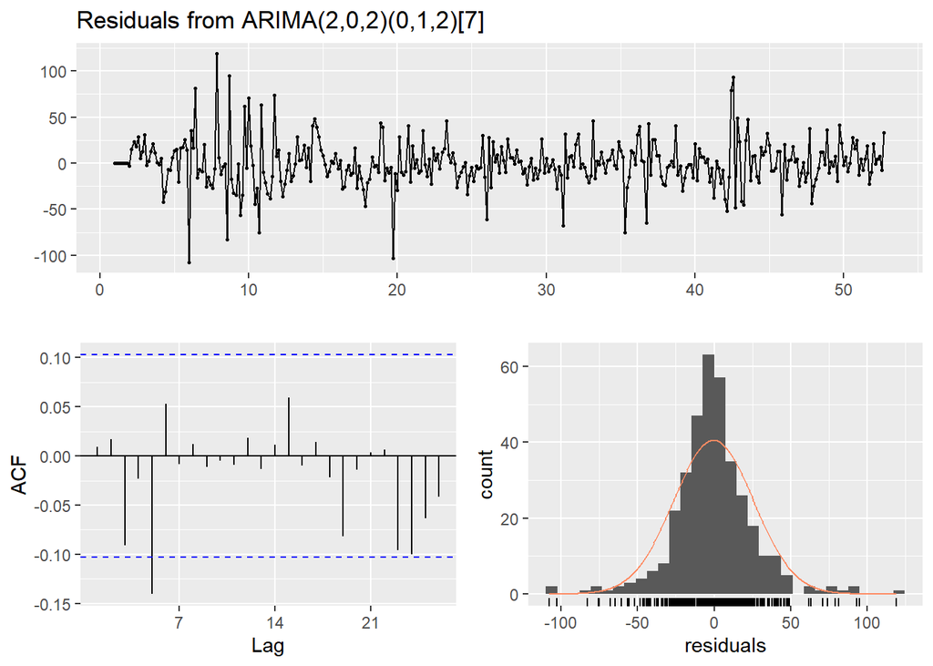

```
##
##  Ljung-Box test
##
## data:  Residuals from ARIMA(2,0,2)(0,1,2)[7]
## Q* = 12.12, df = 8, p-value = 0.1459
##
## Model df: 6.   Total lags used: 14
```

```r
atm2_arima_fit <- auto.arima(ATM2)
checkresiduals(atm2_arima_fit)
```

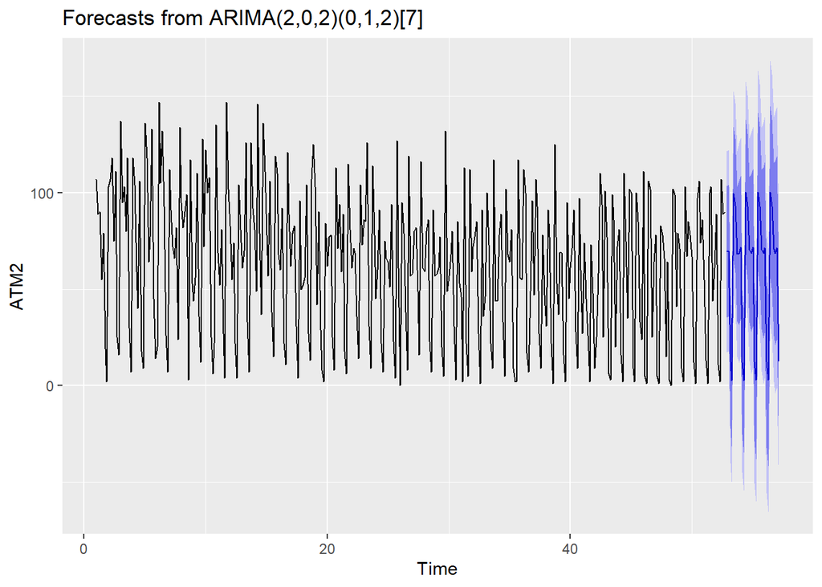

```r
atm2_arima_fit%>% forecast(h=31) %>% autoplot()
```

```r
kpss.test(resid(atm2_arima_fit))
```

```
##
##  KPSS Test for Level Stationarity
##
## data:  resid(atm2_arima_fit)
## KPSS Level = 0.078093, Truncation lag parameter = 5, p-value = 0.1
```